# Lab 4: Binary Logistic Regression

- Show All Code
- Hide All Code
- View Source

Author

Alana Graham

## Introduction

For Lab 4, I will apply binary logistic regression analysis to investigate the factors associated with surviving the Titanic crash. Specifically, I will develop and compare a series of competing models (with passenger age, sex, and ticket class as predictors), evaluate their performance, examine binary logistic regression diagnostics, and interpret the results of my preferred model.

```r
library(glmmTMB)
library(dplyr)
library(tidyr)
library(ggplot2)
library(broom.mixed)
library(performance)
library(gt)
library(readr)
library(DHARMa)
library(ggeffects)
library(titanic)

## Pulling built-in R dataset
titanic <- titanic_train
```

## Descriptives

Based on the descriptive outputs (below), it is not surprising to see that a wide range of ages are represented in the list of passengers (M = 29.70, SD = 14.53). What was more interesting in this sample of 714 is that third class passengers, males, and non-survivors were somewhat over-represented. Furthermore, it is unclear whether these distributions are representative of the full passenger list on the Titanic. The smaller counts are not necessarily concerning, as their values are likely sufficiently large to support comparisons across combinations of predictors and the outcome variable, although their predictive performance and precision may vary. It is also encouraging to see that the number of survivors does not differ drastically from the number of passengers who died. That said, there remains a small amount of unevenness in the distribution, which can influence the precision and stability of logistic regression estimates, particularly for the smaller group.

```r
titanic <- titanic |>
  select(Survived, Sex, Age, Pclass) |> ## Selecting variables of interest
  drop_na() |>
  mutate(Sex.Binary = case_when(
      Sex == "male" ~ 0,
      Sex == "female" ~ 1)) |> ## Giving numerical values to sex categories
  mutate(Survived.Char = case_when(
      Survived == 0 ~ "Died",
      Survived == 1 ~ "Survived")) |> # Giving informative labels to numerically-assigned categories
  mutate(Pclass.Char = case_when(
      Pclass == "1" ~ "First Class",
      Pclass == "2" ~ "Second Class",
      Pclass == "3" ~ "Third Class")) |>
  mutate(Pclass = factor(Pclass, levels = c(1, 2, 3))) |> ## Re-classifying integer vector as factor
  select(Survived, Survived.Char, Sex, Sex.Binary, Pclass, Pclass.Char, Age) ## Expanding dataset to include newly created vectors

descriptives <- titanic |>
  summarise(across(
    c(Age),
    list(mean = mean, sd = sd, min = min, max = max))) |> #Specifying specific descriptive statistics
  pivot_longer(
    everything(),
    names_to = c("variable", ".value"),
    names_sep = "_") ## Transposing values to appear in columns

  gt(descriptives) |>
  fmt_number(columns = where(is.numeric), decimals = 2) ## Producing table with formatted values to two decimal places
```

| variable | mean | sd | min | max |
| --- | --- | --- | --- | --- |
| Age | 29.70 | 14.53 | 0.42 | 80.00 |

```r
descriptives.categorical <- titanic |>
  select(Survived.Char, Sex, Pclass.Char) |> ## Selecting categorical variables
  pivot_longer(everything(),
               names_to = "Variable",
               values_to = "Category") |> ## Transposing values to appear in columns
  count(Variable, Category, name = "n") |> ## Calculating counts
  group_by(Variable) |> ## Grouping stats by factors
  mutate(Variable = recode(Variable,
    Survived.Char = "Survival Status",
    Pclass.Char = "Passenger Class")) |> ## Renaming variables for table
  mutate(Percentage = paste0(round(n / sum(n) * 100, 1), "%")) ## Adding percentages for added context

  gt(descriptives.categorical) |> ## Generating GT table
    tab_options(table.width = px(300)) ## Making columns wider to separate them more cleanly
```

| Category | n | Percentage |
| --- | --- | --- |
| Passenger Class |  |  |
| First Class | 186 | 26.1% |
| Second Class | 173 | 24.2% |
| Third Class | 355 | 49.7% |
| Sex |  |  |
| female | 261 | 36.6% |
| male | 453 | 63.4% |
| Survival Status |  |  |
| Died | 424 | 59.4% |
| Survived | 290 | 40.6% |

## Model Specification

Based on my prior knowledge of the Titanic, I expect to find that younger passengers, female passengers, and first-class passengers were significantly more likely to survive the sinking of the ship. This is because in emergency situations, women and children were often given priority when evacuating to life boats. Additionally, in the Titanic’s case, my understanding is that passengers were first-and-foremost evacuated in order of ticket class, with most third-class passengers barred from accessing the evacuation deck entirely. This situation may have been particularly unusual in the Titanic’s case, as many wealthy passengers were aboard for the ship’s maiden voyage. Combined with an inadequate number of lifeboats and lifeboat evacuations that prioritized passengers’ comfort over maximizing the ratio of people-to-lifeboat, it is expected that first-class passengers were significantly more likely to survive the sinking.

To assess these predictions, I will compare four nested models, with each successive model containing all predictors from the preceding model, plus one or more additional predictors:

| **Model** | **Predictors** | **Purpose** |
| --- | --- | --- |
| mod0: Null | Intercept-only | Establish a baseline |
| mod1: Sex | Sex | Evaluate sex |
| mod2: Sex + Ticket Class | Sex, Ticket Class | Evaluate the additional contribution of ticket class |
| mod3: Sex + Ticket Class + Age | Sex, Ticket Class, Age | Evaluate the additional contribution of age |

```r
mod0 <- glmmTMB(Survived ~ 1,
                data = titanic,
                family = binomial(link = "logit")) ## Intercept-only

mod1 <- glmmTMB(Survived ~ Sex.Binary,
                data = titanic,
                family = binomial(link = "logit")) ## Evaluate sex

mod2 <- glmmTMB(Survived ~ Sex.Binary + Pclass,
                data = titanic,
                family = binomial(link = "logit")) ## Evaluate the additional contribution of ticket class

mod3 <- glmmTMB(Survived ~ Sex.Binary + Pclass + Age,
                data = titanic,
                family = binomial(link = "logit")) ## Evaluate the additional contribution of age
```

In the intercept-only model, the intercept estimate (-0.38, p <.001) represents the log-odds of survival overall. In Model 1, the intercept estimate (-1.35, p <.001) represents the log-odds of survival by male passengers. In Model 2, the intercept estimate (-0.24, p = .192) represents the log-odds of survival by first-class male passengers. Given that the intercept estimate became less negative between Models 1 and 2, this suggests that having a first-class ticket increased males’ likelihood of survival (or rather, decreased this demographic’s likelihood of dying). That said, the estimate is not statistically significant, indicating a lack of evidence that the baseline log-odds of survival differ from zero (equivalent to a survival probability of 50%). In Model 3, the intercept estimate (1.25, p <.001) represents the log-odds of survival by first-class male passengers at 0 years of age. Given the prediction that younger passengers (particularly children) were more likely to survive because of their prioritized evacuation (at least those in first-class), it is unsurprising to see that the intercept’s log-odds increased from Model 2 and is higher in the positive direction.

## Nested Model Comparisons

```r
tests <- anova(mod0, mod1, mod2, mod3) ## Comparing models

tests <- tests |>
  select(Chisq, `Chi Df`, `Pr(>Chisq)`) |>
  rename(Nested.df = `Chi Df`,
    Nested.Chisq.stat = Chisq,
    Nested.p.value = `Pr(>Chisq)`) ## Retaining and renaming relevant statistics

glance0 <- broom.mixed::glance(mod0) ## Extract overall model performance for intercept-only model
glance1 <- broom.mixed::glance(mod1) ## Extract overall model performance for Model 1
glance2 <- broom.mixed::glance(mod2) ## Extract overall model performance for Model 2
glance3 <- broom.mixed::glance(mod3) ## Extract overall model performance for Model 3

mods <- c("mod0: Null",
  "mod1: Sex",
  "mod2: + Ticket Class",
  "mod3: + Age") ## Creating and combining labels of the four models

glances <- rbind(glance0,
  glance1,
  glance2,
  glance3) ## Combining the individual model results

comparison_table <- cbind(Model = mods,
  glances,
  tests) ## Combining the model labels with the two statistical outputs

comparison_table |> ## Producing a combined model comparison table with relevant statistics and formatting
  select(Model,
    AIC,
    BIC,
    logLik,
    deviance,
    df.residual,
    Nested.df,
    Nested.Chisq.stat,
    Nested.p.value) |> ## Selecting relevant stats
  gt() |> ## Formatted as gt table
  cols_label(Model = "Model",
    AIC = "AIC",
    BIC = "BIC",
    logLik = "Log-likelihood",
    deviance = "Deviance",
    df.residual = "Residual.df",
    Nested.df = "Nested df",
    Nested.Chisq.stat = "Nested χ²",
    Nested.p.value = "Nested p") |> ## Providing informative labels for columns
  fmt_number(columns = c(
      AIC,
      BIC,
      logLik,
      deviance,
      Nested.Chisq.stat),
    decimals = 2) |> ## Specifying values at two decimal places, per APA7 guidelines
  fmt(columns = Nested.p.value,
    fns = function(x) {
      ifelse(
        is.na(x),
        "—",
        ifelse(x < .001, "< .001", sprintf("%.3f", x)))}) |> ## Formatting display of p values
  sub_missing(columns = c(Nested.df, Nested.Chisq.stat),
    missing_text = "—") ## Formatting display for missing values
```

| Model | AIC | BIC | Log-likelihood | Deviance | Residual.df | Nested df | Nested χ² | Nested p |
| --- | --- | --- | --- | --- | --- | --- | --- | --- |
| mod0: Null | 966.52 | 971.09 | −482.26 | 964.52 | 713 | — | — | — |
| mod1: Sex | 754.70 | 763.84 | −375.35 | 750.70 | 712 | 1 | 213.82 | < .001 |
| mod2: + Ticket Class | 680.43 | 698.71 | −336.22 | 672.43 | 710 | 2 | 78.27 | < .001 |
| mod3: + Age | 657.28 | 680.14 | −323.64 | 647.28 | 709 | 1 | 25.15 | < .001 |

```r
selected_row <- comparison_table |> ## Filtering to select most complex model with nested p-value < .05
  filter(Nested.p.value < .05) |>
  slice_tail(n = 1)

selected_name <- selected_row$Model ## Creating an object with the selected model's name for dynamic reporting

selected_model <- switch(selected_name,
  "mod0: Null" = mod0,
  "mod1: Sex" = mod1,
  "mod2: + Ticket Class" = mod2,
  "mod3: + Age" = mod3) ## Case matching for dynamic reporting
```

The results suggest that Model 3 provides the best fit to the data. Even though this model is the most complex, the AIC and BIC values (which decrease between each successive model and are designed to penalize model complexity) are the lowest. Additionally, the significant likelihood-ratio tests (χ²) suggest that each successive model fits the data significantly (p < .001) better than the previous one. The log-likelihood values, which become less negative with each successive model, also support this. Notably, while AIC, BIC, and likelihood-ratio tests all measure model fit, AIC and BIC penalize model complexity, whereas likelihood-ratio tests specifically compare the fit of a model to the fit of an earlier model. Overall, each predictor appears to contribute significant added value to the model, although there are diminishing returns.

Thus, the provisionally selected model is **mod3: + Age**.

Its performance is: - AIC = **657.28** - BIC = **680.14**

## Evaluating binary logistic regression diagnostics

The plots below depict some of the assumption checks conducted for Model 3. Scroll past to see my interpretations!

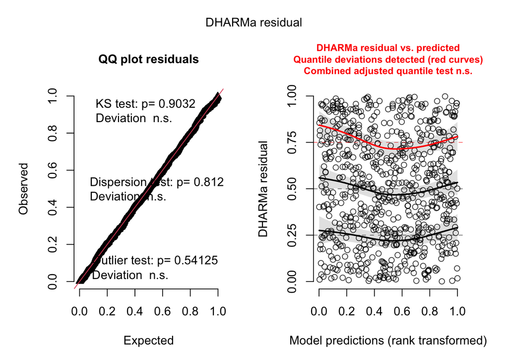

```r
set.seed(9041) ## Selecting the course number as the arbitrary seed for simulation of residuals
res_mod3 <- simulateResiduals(mod3, n = 500, plot = FALSE)

#| fig-height: 5.6
plot(res_mod3) #Plotting the above simulation to create a default DHARMa plot
```

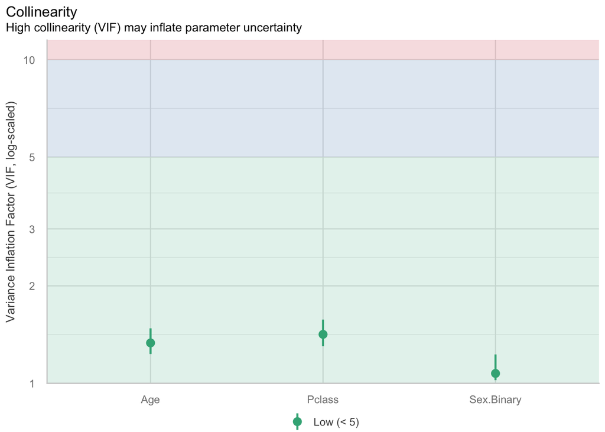

```r
vif_plot <- plot(check_collinearity(mod3)) ## Plotting the VIF values calculated above

vif_plot ## Displaying plot
```

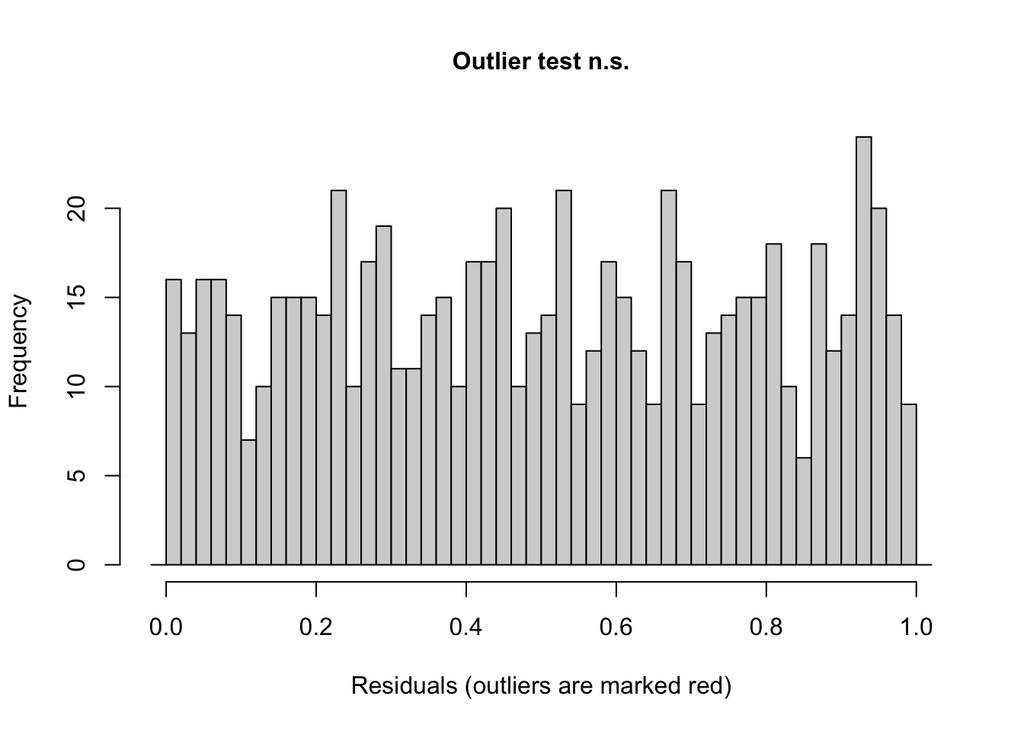

```r
check_collinearity(mod3) ## Checking for multi-collinearity of predictors

testOutliers(res_mod3) ## Testing for outliers
```

```r
fitted_probs <- predict(mod3, type = "response") ## Checking for indicators of separation (i.e., fitted probabilities off essentially 0 or 1)

summary(fitted_probs) ## Generating summary table with minimum and maximum probability values

n_event <- sum(titanic$Survived == 1) ## Generating number of survivors
n_nonevent <- sum(titanic$Survived == 0) ## Generating number of non-survivors
n_coef <- length(fixef(mod3)$cond) ## Generating number of coefficients in the model

EPV_event <- n_event/n_coef
EPV_nonevent <- n_nonevent/n_coef
```

Linearity to the logit scale: The residuals do not deviate substantially from a uniform distribution on the scale and, although there are slight curvatures apparent in the plot depicting residuals vs. predicted values, residual variability does not significantly change across fitted values on the log-odds scale.

Collinearity: The VIF values are very low, suggesting that predictors are not so strongly related that their unique contributions may be difficult to estimate precisely.

Complete separation: None of the coefficients or standard errors were very large, there were no `glmmTMB`warnings about convergence, and none of the predictors perfectly predicts the outcome variable.

Influential observations: No significant outliers were identified that may disproportionately influence the fitted model. Cook’s distance is not implemented for `glmmTMB`, so I could not check for influential observations

Events per Prediction: Here we have 290 survivors and 424 non-survivors, with 5 coefficients in Model 3. This suggests that the number of events per prediction (58 for survivors, 84.8 for non-survivors) for both outcomes were more than satisfactory for the model.

Consequently, no major diagnostic concerns were identified that would significantly undermine confidence in this model or its findings. Therefore, the results can be interpreted with reasonable confidence.

## Selecting and Reporting the Preferred Model

Model 3 is more appropriate than the alternatives because it provides the best balance of model fit and complexity, accounting for all three theoretically relevant predictors. Compared with the preceding models, Model 3 had the lowest AIC and BIC values, indicating the best relative fit even after penalizing for additional parameters. The significant likelihood-ratio test indicates that adding age significantly improves model fit beyond what is explained by sex and passenger class alone. Moreover, all three predictors significantly predicted the odds of survival. Importantly, the diagnostic results revealed no apparent concerns regarding linearity, collinearity, complete separation, outliers, or the number of events relative to model parameters. Thus, Model 3 offers the most comprehensive and best-fitting explanation of survival without evidence that its additional complexity substantially compromises the reliability of its estimates.

```r
  ## Coefficient Table
coefficient_results <- broom.mixed::tidy(selected_model,
  effects = "fixed",
  component = "cond",
  conf.int = TRUE,
  conf.level = 0.95) ## Extracting coefficient-level results from the fitted binary logistic regression model

coefficient_results |>
  select(term, ## Selecting relevant values
    estimate,
    std.error,
    conf.low,
    conf.high,
    p.value) |>
  mutate(term = recode(term,
    "(Intercept)" = "Intercept",
    "Sex.Binary" = "Sex (Female)",
    "Pclass2" = "Second Class",
    "Pclass3" = "Third Class",
    "Age" = "Age")) |>
  gt() |> ## Formatting as gt table
  cols_label(term = "Predictor",
    estimate = "Estimate",
    std.error = "SE",
    conf.low = "95% CI lower",
    conf.high = "95% CI upper",
    p.value = "p") |> ## Renaming columns
  fmt_number(columns = c(estimate,
      std.error,
      conf.low,
      conf.high),
    decimals = 2) |> ## Formatting values to two decimal places
  fmt(columns = p.value,
    fns = function(x) {
      ifelse(x < .001,
        "< .001",
        sprintf("%.3f", x))}) ## Formatting p-values
```

| Predictor | Estimate | SE | 95% CI lower | 95% CI upper | p |
| --- | --- | --- | --- | --- | --- |
| Intercept | 1.25 | 0.36 | 0.55 | 1.96 | < .001 |
| Sex (Female) | 2.52 | 0.21 | 2.12 | 2.93 | < .001 |
| Second Class | −1.31 | 0.28 | −1.85 | −0.76 | < .001 |
| Third Class | −2.58 | 0.28 | −3.13 | −2.03 | < .001 |
| Age | −0.04 | 0.01 | −0.05 | −0.02 | < .001 |

```r
fixef(mod3) ## Extracting fixed-effect coefficient estimates for each predictor
round(fixef(mod3)$cond[["Sex.Binary"]], 2)
round(fixef(mod3)$cond[["Pclass2"]], 2)
round(fixef(mod3)$cond[["Pclass3"]], 2)
round(fixef(mod3)$cond[["Age"]], 2)

exp(fixef(mod3)$cond) ## Exponentiating odds ratios
or_ci <- exp(confint(mod3, parm = "beta_")) ## ... and their 95% confidence intervals
```

The coefficients represent changes in the log-odds of surviving the Titanic sinking, holding the other predictors constant.

#### Interpreting Sex

The coefficient for Sex (female) represents the log-odds difference between female and male passengers, holding age and ticket class constant. Recall that male passengers are the reference group (coded 0), therefore the log-odds of survival increase by 2.52 for female passengers compared to male passengers, holding age and ticket class constant.

Holding ticket class and age constant, female passengers had 12.46 times the odds of surviving, 95% CI [8.3, 18.71].

#### Interpreting Ticket Class

The coefficient for second-class passengers represents the log-odds difference between second- and first-class passengers, holding sex and age constant. Recall that first class is the reference group, therefore the log-odds of survival change by -1.31 for second-class passengers compared to first-class passengers, holding sex and age constant.

Holding sex and age constant, second-class passengers had 0.27 times the odds of surviving, 95% CI [0.16, 0.47].

The coefficient for third-class passengers represents the log-odds difference between third- and first-class passengers, holding sex and age constant. Therefore, the log-odds of survival change by -2.58 for third-class passengers compared to first-class passengers, holding sex and age constant.

Holding sex and age constant, third-class passengers had 0.08 times the odds of surviving, 95% CI [0.04, 0.13].

#### Interpreting Age

Finally, for every one-unit increase in age (holding sex and passenger class constant) the log-odds of survival decrease slightly by 0.04.

Holding sex and ticket class constant, a one-point increase in age is associated with 0.96 times the odds of surviving, 95% CI [0.95, 0.98].

#### Summary of Analyses

This analysis used a binomial GLM with a logit link to examine whether passenger sex, ticket class, and age predicted surviving the sinking of the Titanic. After excluding observations with missing values on the variables of interest, the final sample consisted of 714 passengers. Descriptive statistics indicated that the sample had a mean age of 29.70 years (SD = 14.53), with males, third-class passengers, and non-survivors somewhat over-represented.

Four nested logistic regression models were compared. The null (intercept-only) model included no predictors; Model 1 added sex (i.e., male or female); Model 2 added passenger class (1st, 2nd, 3rd); and Model 3 added age. Likelihood-ratio tests indicated that each successive model significantly improved fit over the preceding model (all p < .001). Model 3 also had the lowest AIC and BIC, suggesting the best relative fit, even after accounting for model complexity. Therefore, Model 3, which included all predictors, was selected as the preferred model. The diagnostic checks for this model did not identify apparent concerns with linearity, collinearity, complete separation, outliers, or events per prediction.

```r
  ## Model Performance Table
selected_row |>
  select(Model,
    AIC,
    BIC,
    logLik,
    deviance,
    df.residual,
    Nested.df,
    Nested.Chisq.stat,
    Nested.p.value) |> ## Selecting relevant statistics
  gt() |> ## Formatting as gt table
  cols_label(Model = "Model",
    AIC = "AIC",
    BIC = "BIC",
    logLik = "Log-likelihood",
    deviance = "Deviance",
    df.residual = "Residual df",
    Nested.df = "Nested df",
    Nested.Chisq.stat = "Nested χ²",
    Nested.p.value = "Nested p") |> ## Adding informative column labels
  fmt_number(columns = c(AIC,
                         BIC,
                         logLik,
                         deviance,
                         df.residual,
                         Nested.df,
                         Nested.Chisq.stat),
                decimals = 2) |> ## Formatting numbers to two decimal places
  fmt(columns = Nested.p.value,
    fns = function(x) {
      ifelse(x < .001,
        "< .001",
        sprintf("%.3f", x))}) ## Formatting p-value
```

| Model | AIC | BIC | Log-likelihood | Deviance | Residual df | Nested df | Nested χ² | Nested p |
| --- | --- | --- | --- | --- | --- | --- | --- | --- |
| mod3: + Age | 657.28 | 680.14 | −323.64 | 647.28 | 709.00 | 1.00 | 25.15 | < .001 |

The results found that female passengers had higher odds of surviving the Titanic’s sinking, OR = 12.46, 95% CI [8.3, 18.71]. Compared to first-class passengers, second-class passengers had significantly lower odds of surviving, OR = 0.27, 95% CI [0.16, 0.47]. Unsurprisingly, third-class passengers had even lower survival odds, OR = 0.08, 95% CI [0.04, 0.13]. As depicted in the plot below, older passengers also had lower odds of surviving the sinking, OR = 0.96, 95% CI [0.95, 0.98].

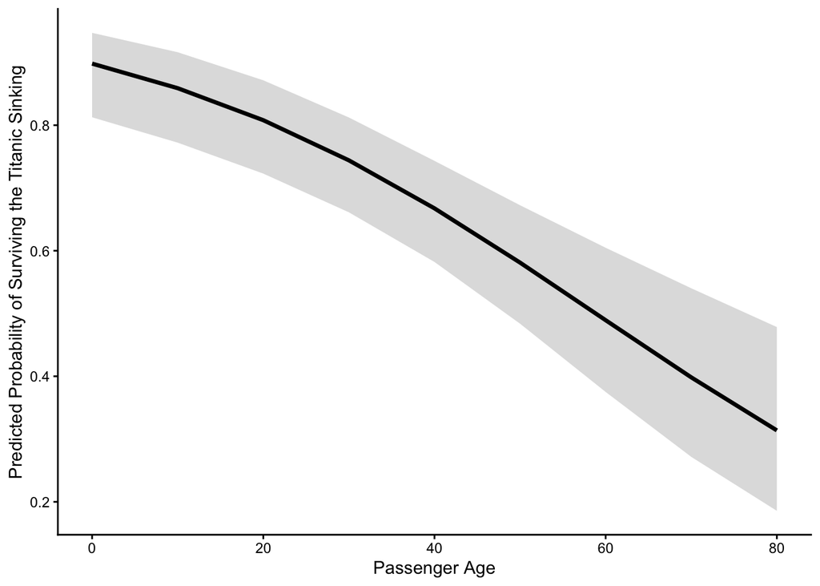

```r
pred_age <- ggpredict(mod3, terms = "Age")

ggplot(pred_age, aes(x, predicted)) +
  geom_ribbon(aes(ymin = conf.low, ymax = conf.high), alpha = 0.18) +
  geom_line(linewidth = 1.2) +
  labs(x = "Passenger Age",
       y = "Predicted Probability of Surviving the Titanic Sinking") +
  theme_classic()
```

## Substantive Conclusions

The results suggest that sex was the strongest predictor of survival, with women having substantially higher odds of survival than men, even after controlling for the influence of ticket class and age. Ticket class was also an important predictor: passengers in second- and (particularly) third-class had significantly lower odds of survival compared to first-class passengers, suggesting that socioeconomic status may have influenced access to survival opportunities. Age was also associated with survival, with older passengers having lower odds of survival, although its effect appeared more modest than those of sex and ticket class.

Several limitations should be considered. First, ticket class is only a proxy for socioeconomic status and may also reflect factors like closer access to the upper deck and evacuation routes. It is also possible that passengers in second- or third-class were not necessarily low in SES, but selected these classes of tickets for other reasons (e.g., frugality). Second, this analysis relies on cross-sectional data, so these associations cannot establish that sex, class, or age directly *caused* differences in survival. Third, other potentially relevant factors (e.g., family status, cabin location) were not included. Fourth, the results cannot speak to the reasons *why* the identified demographic groups had higher or lower odds of survival; therefore, related conclusions are speculative. Finally, the analysis excluded passengers with missing data, which may introduce bias if they differed systematically from those included in the sample. Thus, the findings highlight meaningful associations with survival but should not be interpreted as a complete explanation of why passengers survived or died.